# COVID

# My unique Visualizations and Modelling

## Let’s look at the new death per new case rate. This may give us some insight on the severity of the disease.

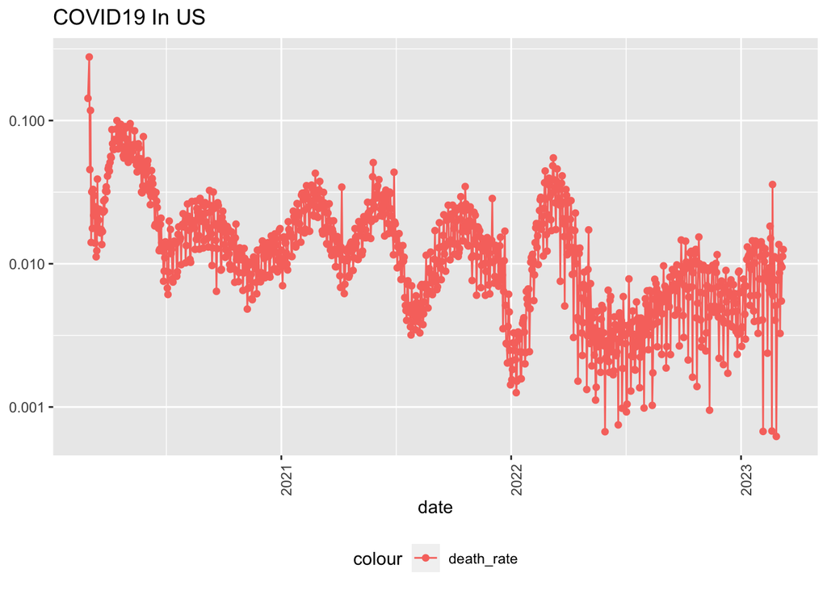

## Colorado’s new death per new case rate

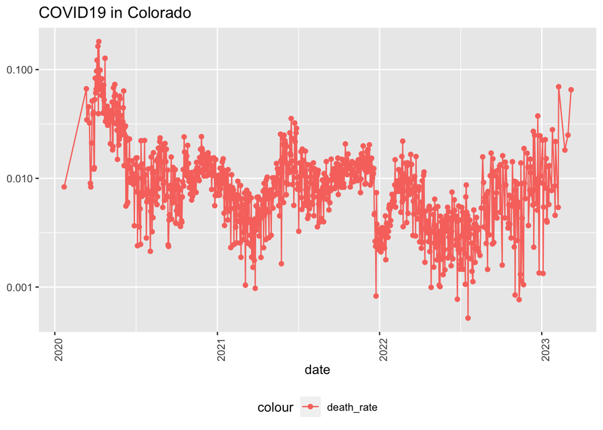

## Modeling: Can the colorado new death/case rate predict the US new death/case rate?

```
##
## Call:
## lm(formula = death_rate.x ~ death_rate.y, data = colorado_us_model)
##
## Residuals:
##       Min        1Q    Median        3Q       Max
## -0.122621 -0.009297 -0.003949  0.003831  0.078382
##
## Coefficients:
##               Estimate Std. Error t value Pr(>|t|)
## (Intercept)  0.0151342  0.0004936  30.661  < 2e-16 ***
## death_rate.y 0.1088322  0.0130823   8.319  2.8e-16 ***
## ---
## Signif. codes:  0 '***' 0.001 '**' 0.01 '*' 0.05 '.' 0.1 ' ' 1
##
## Residual standard error: 0.01495 on 1025 degrees of freedom
## Multiple R-squared:  0.06325,    Adjusted R-squared:  0.06233
## F-statistic: 69.21 on 1 and 1025 DF,  p-value: 2.802e-16
```

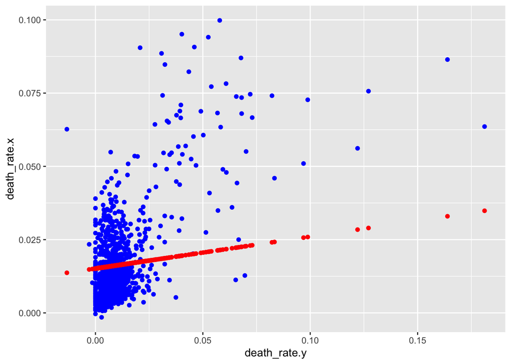

## Discussion:

Even though the single linear regression model shows that colorodo death per case rate is a significant predictor of US death per case rate, after looking at the graph it is clear that future work is needed to improve the model. This model is underestimating death rates at higher values. In other words, the model is predicting the US would have higher death rates for higher vaules of Colorado death rates. In future work, we could explore other models and add more predictors.

## Bias Discussion

There are several sources of potential bias in this data. Different states likely have varying degrees of collecting and reporting covid data, which would have a big impact. Additionally, especially in more recent years, there are likely many more cases going unreported since people are not testing at the same frequency.